# Climate Data RandomForest Analysis - unhealthy tree number response

Joey Hulbert

4/8/2022

# Purpose

The purpose of this markdown document is to list the steps we followed for refining the models using climate data only.

# Data

The data used in the below models are described in the Data Wrangle folder.

## Response variables

**Note the below analysis uses the iNat data with 1510 observations. Amazing!**

- Response variables to consider
  - Number of unhealthy trees

## Explanatory variables

- Explanatory variables included
  - Climate data
    - 30yr normals 1991-2020 (265 variables)

> Note that we included na.string=“-9999” when reading data.

# Data wrangling

There are multiple methods to group the response variables deepening on desired resolution or fineness of the model.

We also need to filter the data to only include response and explanatory variables we’re interested in. For example, whether a sound clip was included in the iNat data is not important. We also need to remove other response variables like “field.percent.canopy.affected….” so it is not used as a predictor for tree health.

> Note it might be interesting to know if the user was an important factor in predicting if the tree is healthy/unhealthy.

There are also a number of factors that should probably be removed because they may be biasing the data. For example, only trees with the ‘other factor’ question may only be answered for unhealthy trees. We need to think about this a bit more.

First remove iNat factors not useful as explanatory variables (e.g. observed_on)

Then, remove specific climate variables not useful as explanatory variables (e.g. norm_Latitutde)

Remove variables with variables that have near zero standard deviations (entire column is same value)

# Approach

# Models

- Random forest model criteria
  - nearzero variation columns were removed
  - Data were imputed prior to model building.
  - number of splits was not defined to allow automatic selection,
  - ntree = 2001, importance = TRUE, proximity = TRUE, na.action = na.omit
  - seed was set for reproducability with: set.seed(71)

### Number of unhealthy trees response variable

Remove variables with variables that have near zero standard deviations (entire column is same value)

#### Normal, Monthless Model

```
##
## Call:
##  randomForest(formula = field.number.of.additional.unhealthy.trees..of.same.species..in.area..within.sight. ~      ., data = normal.monthless.combo.filtered.nearzerovar, ntree = 2001,      importance = TRUE, proximity = TRUE, na.action = na.omit)
##                Type of random forest: classification
##                      Number of trees: 2001
## No. of variables tried at each split: 8
##
##         OOB estimate of  error rate: 41.53%
## Confusion matrix:
##                0  1 2-3 4-6 7-10 More than 10 Not sure class.error
## 0            770 45  43  27    5           13       10   0.1566265
## 1             86 16  11   9    2            2        1   0.8740157
## 2-3           97  9  26  17    4            4        3   0.8375000
## 4-6           61  7  16  49    6           13        0   0.6776316
## 7-10          13  2   4   5    8            8        1   0.8048780
## More than 10  37  2   6  14    5            9        1   0.8783784
## Not sure      27  1   3   1    1            3        2   0.9473684
```

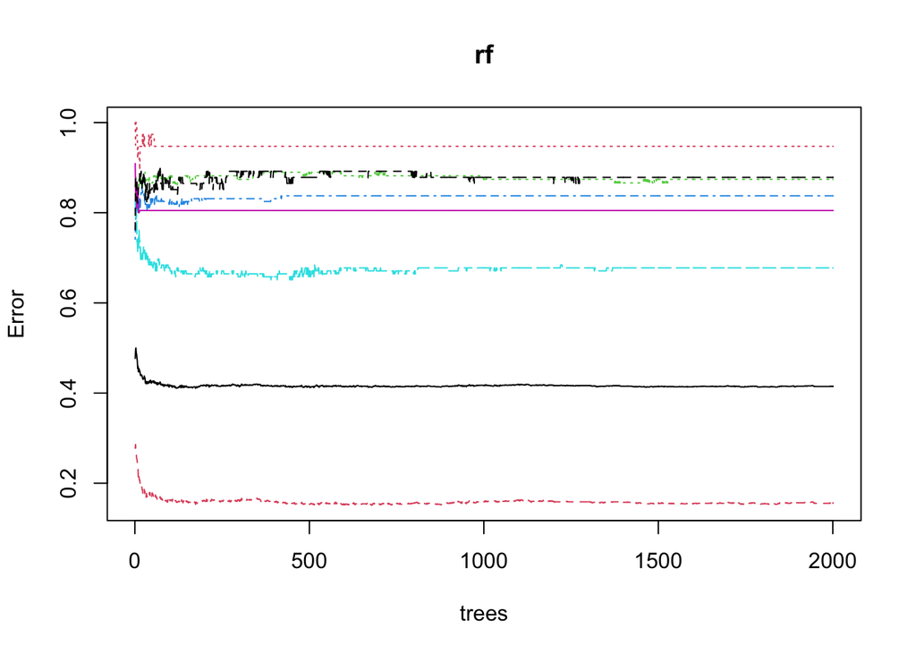

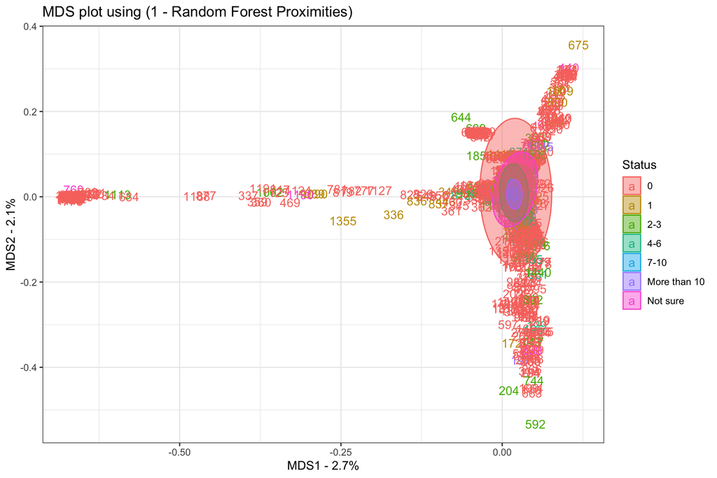

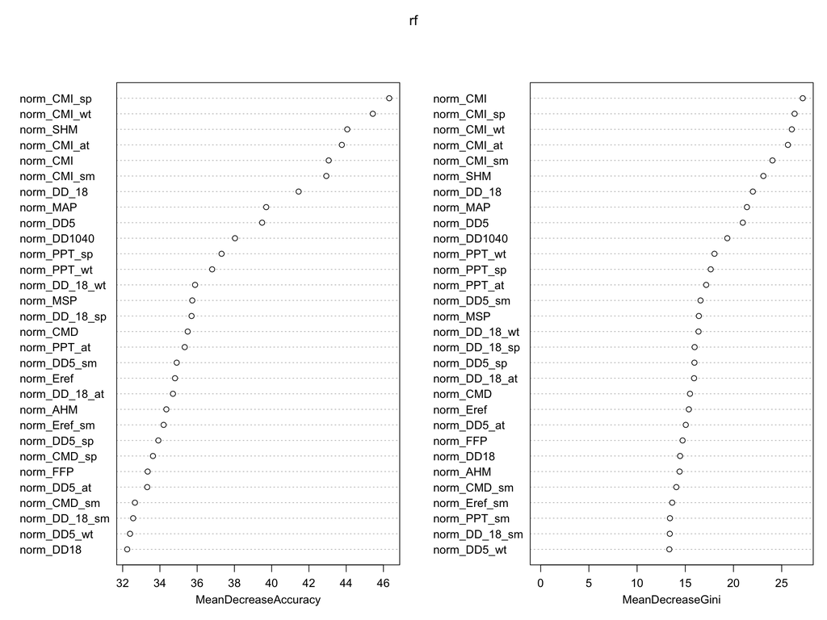

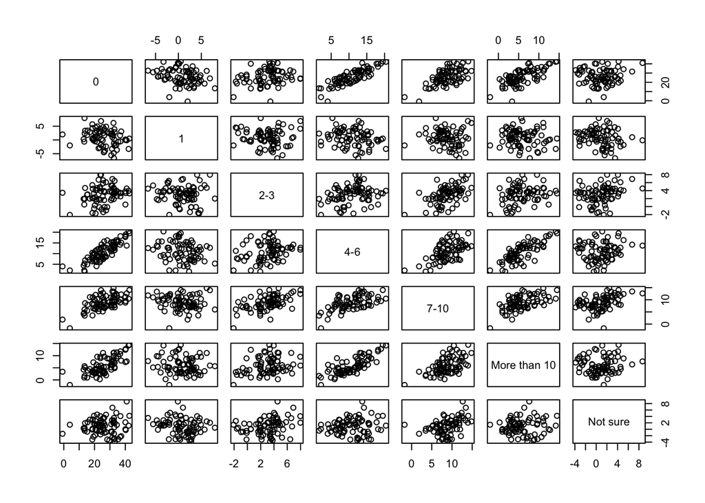